# CancerCovid Endocrine Tx Preliminary Analyses

Nicola Barclay

2023-07-14

### Cancer/ Covid Breast and Prostate Cancer Endocrine Treatment Preliminary Analyses

#### 1. Incidence of the use of endocrine treatments for breast and prostate cancer in the general population.

Denominator cohorts specified in the Incidence/Prevalence package with 365 days prior history:

```
##    cohort_definition_id number_records number_subjects           cohort_name
## 1                     1  2.870676e-317   2.870676e-317  Denominator cohort 1
## 2                     2  2.618291e-317   2.618291e-317  Denominator cohort 2
## 3                     3  1.413861e-317   1.413861e-317  Denominator cohort 3
## 4                     4  1.294701e-317   1.294701e-317  Denominator cohort 4
## 5                     5  1.456815e-317   1.456815e-317  Denominator cohort 5
## 6                     6  1.323590e-317   1.323590e-317  Denominator cohort 6
## 7                     7  6.902389e-318   6.902389e-318  Denominator cohort 7
## 8                     8  6.122229e-318   6.122229e-318  Denominator cohort 8
## 9                     9  3.500248e-318   3.500248e-318  Denominator cohort 9
## 10                   10  3.121517e-318   3.121517e-318 Denominator cohort 10
## 11                   11  3.402141e-318   3.402141e-318 Denominator cohort 11
## 12                   12  3.000713e-318   3.000713e-318 Denominator cohort 12
## 13                   13  9.415873e-318   9.415873e-318 Denominator cohort 13
## 14                   14  8.243317e-318   8.243317e-318 Denominator cohort 14
```

[output cut: 96 more lines]

#### 1a. Incidence Rates of Endocrine Treatments for Breast or Prostate Cancer in Quarters

#### in the General Population Before and After COVID-19 Lockdown

#### (365 days prior history, 90 days washout)

```
## here() starts at /home/AD_NDORMS/nbarclay/R/CancerCovidEndocrineTx
```

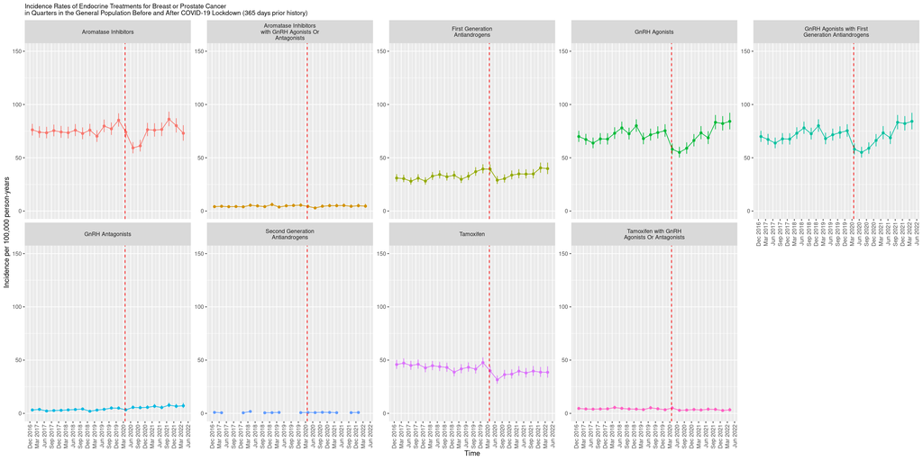

### 2. Incidence of the use of endocrine treatments for breast cancer in breast cancer patients

Breast cancer strata cohorts specified in the Incidence/Prevalence package with 0/365 days prior history:

```
## # A tibble: 30 × 12
##    cohort_definition_id number_records number_subjects cohort_name     age_group
##                   <int>        <int64>         <int64> <chr>           <chr>
##  1                    1      7.28e-320       7.28e-320 Denominator co… 0 to 150
##  2                    2      6.81e-320       6.81e-320 Denominator co… 0 to 150
##  3                    3      7.23e-320       7.23e-320 Denominator co… 0 to 150
##  4                    4      6.77e-320       6.77e-320 Denominator co… 0 to 150
##  5                    5      4.50e-322       4.50e-322 Denominator co… 0 to 150
##  6                    6      4.25e-322       4.25e-322 Denominator co… 0 to 150
##  7                    7      2.88e-321       2.88e-321 Denominator co… 20 to 39
##  8                    8      2.55e-321       2.55e-321 Denominator co… 20 to 39
##  9                    9      2.87e-321       2.87e-321 Denominator co… 20 to 39
## 10                   10      2.54e-321       2.54e-321 Denominator co… 20 to 39
## # ℹ 20 more rows
## # ℹ 7 more variables: sex <chr>, days_prior_history <dbl>, start_date <date>,
## #   end_date <date>, strata_cohort_definition_id <dbl>,
## #   strata_cohort_name <chr>, closed_cohort <lgl>
```

#### 2a. Incidence Rates of Endocrine Treatments for Breast Cancer in Quarters

#### in Breast Cancer Patients Before and After COVID-19 Lockdown

#### (0 days prior history, 90 days washout)

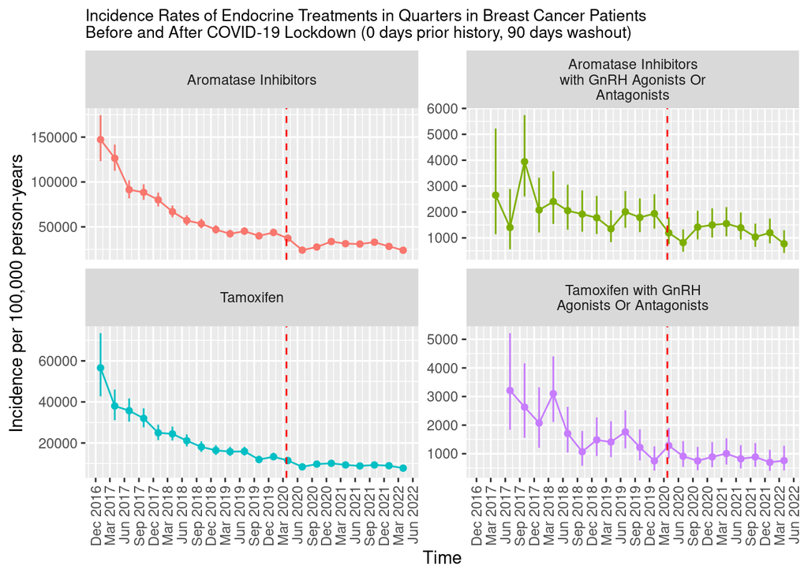

#### 2b. Incidence Rates of Endocrine Treatments for Breast Cancer in Quarters

#### in Breast Cancer Patients Before and After COVID-19 Lockdown

#### (365 days prior history, 90 days washout)

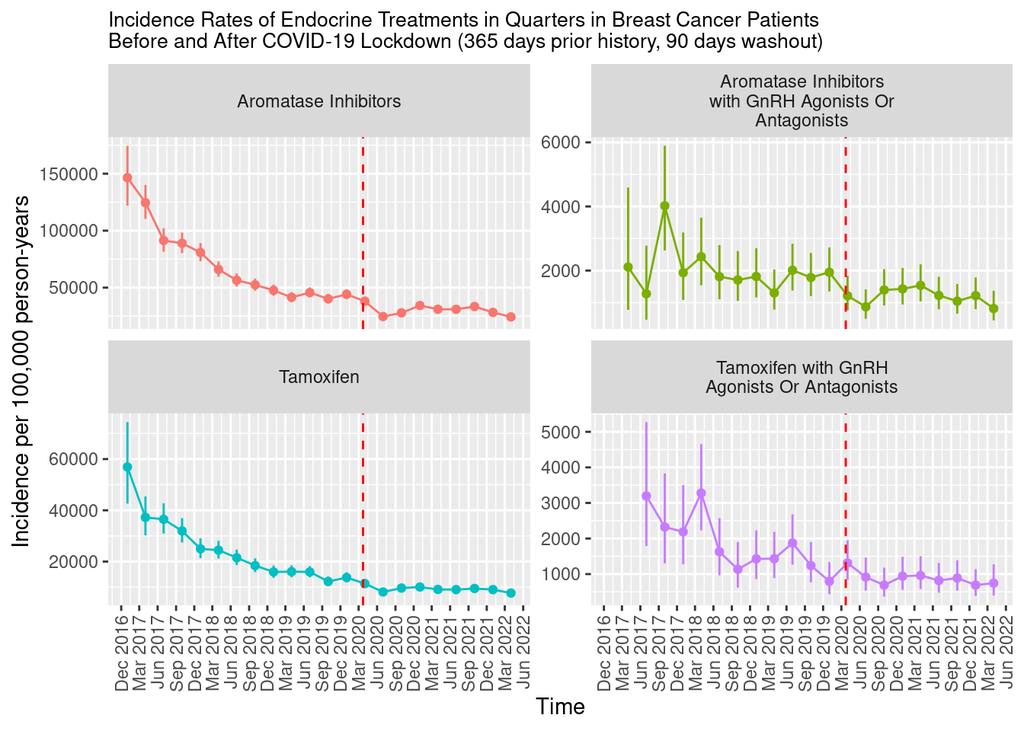

### 3. Incidence of the use of endocrine treatments for prostate cancer in prostate cancer patients

Prostate cancer strata cohorts specified in the Incidence/Prevalence package with 0/365 days prior history:

```
## # A tibble: 10 × 12
##    cohort_definition_id number_records number_subjects cohort_name     age_group
##                   <int>        <int64>         <int64> <chr>           <chr>
##  1                    1      6.36e-320       6.36e-320 Denominator co… 0 to 150
##  2                    2      6.04e-320       6.04e-320 Denominator co… 0 to 150
##  3                    3      3.46e-323       3.46e-323 Denominator co… 20 to 39
##  4                    4      2.47e-323       2.47e-323 Denominator co… 20 to 39
##  5                    5      6.55e-321       6.55e-321 Denominator co… 40 to 59
##  6                    6      6.15e-321       6.15e-321 Denominator co… 40 to 59
##  7                    7      4.55e-320       4.55e-320 Denominator co… 60 to 79
##  8                    8      4.35e-320       4.35e-320 Denominator co… 60 to 79
##  9                    9      1.16e-320       1.16e-320 Denominator co… 80 to 150
## 10                   10      1.07e-320       1.07e-320 Denominator co… 80 to 150
## # ℹ 7 more variables: sex <chr>, days_prior_history <dbl>, start_date <date>,
## #   end_date <date>, strata_cohort_definition_id <dbl>,
## #   strata_cohort_name <chr>, closed_cohort <lgl>
```

#### 3a. Incidence Rates of Endocrine Treatments for Prostate Cancer in Quarters

#### in Prostate Cancer Patients Before and After COVID-19 Lockdown

#### (0 days prior history, 90 days washout)

```
## `geom_line()`: Each group consists of only one observation.
## ℹ Do you need to adjust the group aesthetic?
```

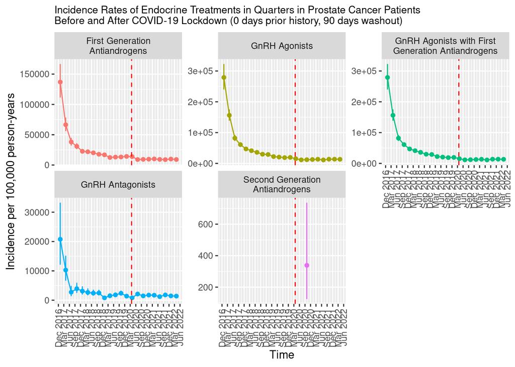

#### 3b. Incidence Rates of Endocrine Treatments for Prostate Cancer in Quarters

#### in Prostate Cancer Patients Before and After COVID-19 Lockdown

#### (365 days prior history, 90 days washout)

```
## `geom_line()`: Each group consists of only one observation.
## ℹ Do you need to adjust the group aesthetic?
```

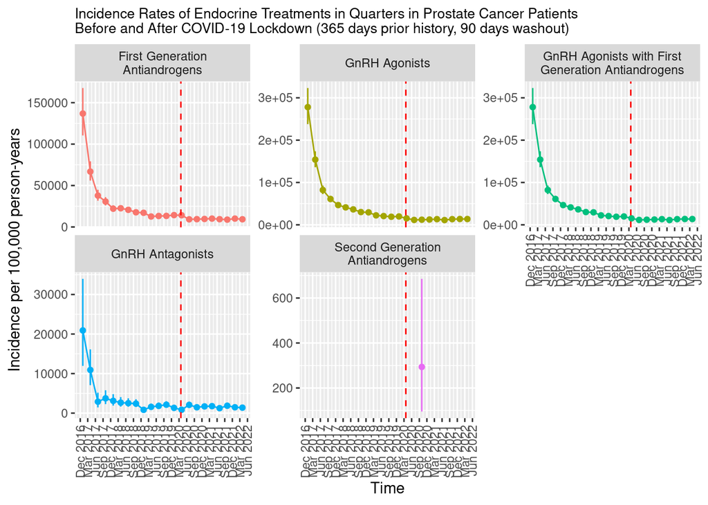

### 4. Incidence of endocrine treatment-related outcomes for breast cancer patients

### on Aromatase Inhibitors

Breast cancer patients on aromatase inhibitors strata cohorts specified in the Incidence/Prevalence package with 0/365 days prior history:

```
## # A tibble: 30 × 12
##    cohort_definition_id number_records number_subjects cohort_name     age_group
##                   <int>        <int64>         <int64> <chr>           <chr>
##  1                    1      6.58e-320       5.97e-320 Denominator co… 0 to 150
##  2                    2      5.77e-320       5.21e-320 Denominator co… 0 to 150
##  3                    3      6.57e-320       5.95e-320 Denominator co… 0 to 150
##  4                    4      5.76e-320       5.20e-320 Denominator co… 0 to 150
##  5                    5      1.63e-322       1.58e-322 Denominator co… 0 to 150
##  6                    6      1.33e-322       1.28e-322 Denominator co… 0 to 150
##  7                    7      7.11e-322       6.57e-322 Denominator co… 20 to 39
##  8                    8      5.83e-322       5.29e-322 Denominator co… 20 to 39
##  9                    9      7.11e-322       6.57e-322 Denominator co… 20 to 39
## 10                   10      5.83e-322       5.29e-322 Denominator co… 20 to 39
## # ℹ 20 more rows
## # ℹ 7 more variables: sex <chr>, days_prior_history <dbl>, start_date <date>,
## #   end_date <date>, strata_cohort_definition_id <dbl>,
## #   strata_cohort_name <chr>, closed_cohort <lgl>
```

#### 4a. Incidence Rates of endocrine treatment-related outcomes for breast cancer patients

#### on Aromatase Inhibitors in Quarters Before and After COVID-19 Lockdown

#### (0 days prior history, 90 days washout)

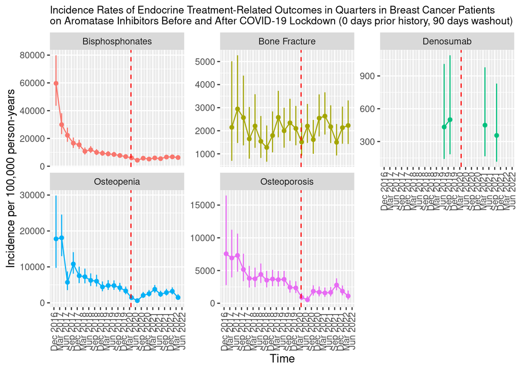

#### 4b. Incidence Rates of endocrine treatment-related outcomes for breast cancer patients

#### on Aromatase Inhibitors in Quarters Before and After COVID-19 Lockdown

#### (365 days prior history, 90 days washout)

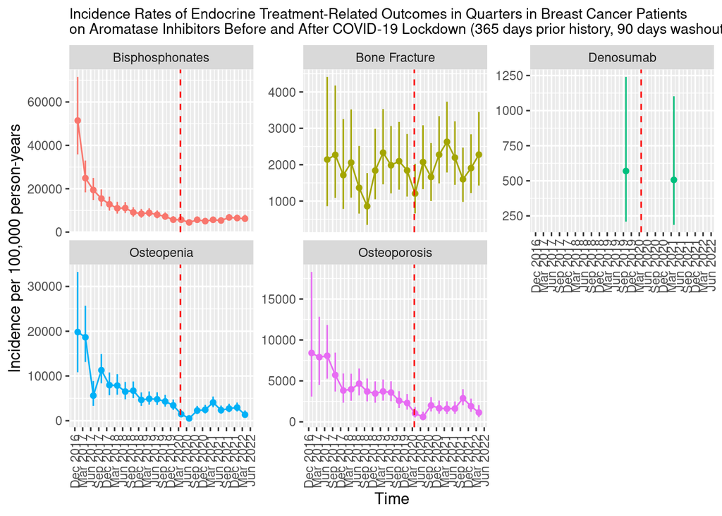

### 5. Incidence of endocrine treatment-related outcomes for breast cancer patients

### on Tamoxifen

Breast cancer patients on tamoxifen strata cohorts specified in the Incidence/Prevalence package with 0/365 days prior history:

```
## # A tibble: 30 × 12
##    cohort_definition_id number_records number_subjects cohort_name     age_group
##                   <int>        <int64>         <int64> <chr>           <chr>
##  1                    1      3.23e-320       2.79e-320 Denominator co… 0 to 150
##  2                    2      2.80e-320       2.40e-320 Denominator co… 0 to 150
##  3                    3      3.19e-320       2.75e-320 Denominator co… 0 to 150
##  4                    4      2.77e-320       2.37e-320 Denominator co… 0 to 150
##  5                    5      4.20e-322       3.80e-322 Denominator co… 0 to 150
##  6                    6      3.75e-322       3.36e-322 Denominator co… 0 to 150
##  7                    7      1.91e-321       1.66e-321 Denominator co… 20 to 39
##  8                    8      1.58e-321       1.35e-321 Denominator co… 20 to 39
##  9                    9      1.90e-321       1.65e-321 Denominator co… 20 to 39
## 10                   10      1.57e-321       1.34e-321 Denominator co… 20 to 39
## # ℹ 20 more rows
## # ℹ 7 more variables: sex <chr>, days_prior_history <dbl>, start_date <date>,
## #   end_date <date>, strata_cohort_definition_id <dbl>,
## #   strata_cohort_name <chr>, closed_cohort <lgl>
```

#### 5a. Incidence Rates of endocrine treatment-related outcomes for breast cancer patients

#### on Tamoxifen in Quarters Before and After COVID-19 Lockdown

#### (0 days prior history, 90 days washout)

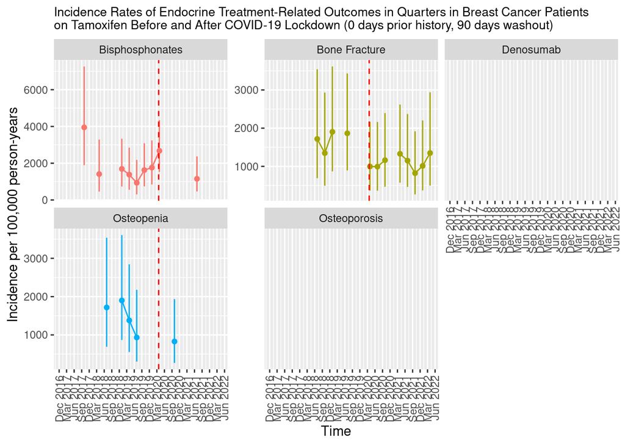

#### 5b. Incidence Rates of endocrine treatment-related outcomes for breast cancer patients

#### on Tamoxifen in Quarters Before and After COVID-19 Lockdown

#### (365 days prior history, 90 days washout)

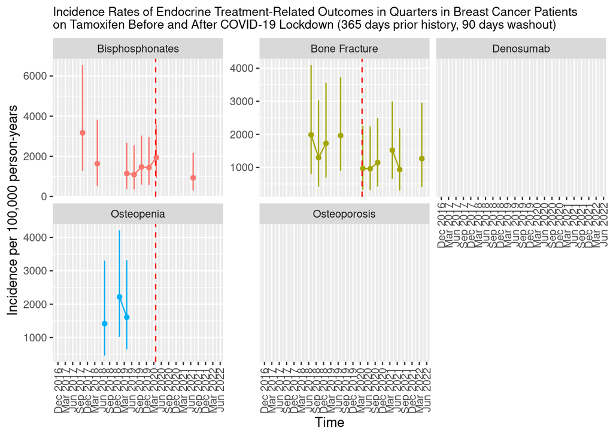

### 6. Incidence of endocrine treatment-related outcomes for prostate cancer patients

### on endocrine treatments

Prostate cancer patients on endocrine treatments strata cohorts specified in the Incidence/Prevalence package with 0/365 days prior history:

```
## # A tibble: 10 × 12
##    cohort_definition_id number_records number_subjects cohort_name     age_group
##                   <int>        <int64>         <int64> <chr>           <chr>
##  1                    1      6.79e-320       5.50e-320 Denominator co… 0 to 150
##  2                    2      6.24e-320       5.02e-320 Denominator co… 0 to 150
##  3                    3      4.94e-324       4.94e-324 Denominator co… 20 to 39
##  4                    4      4.94e-324       4.94e-324 Denominator co… 20 to 39
##  5                    5      2.43e-321       2.22e-321 Denominator co… 40 to 59
##  6                    6      2.22e-321       2.03e-321 Denominator co… 40 to 59
##  7                    7      4.30e-320       3.63e-320 Denominator co… 60 to 79
##  8                    8      4.02e-320       3.38e-320 Denominator co… 60 to 79
##  9                    9      2.25e-320       1.73e-320 Denominator co… 80 to 150
## 10                   10      1.99e-320       1.51e-320 Denominator co… 80 to 150
## # ℹ 7 more variables: sex <chr>, days_prior_history <dbl>, start_date <date>,
## #   end_date <date>, strata_cohort_definition_id <dbl>,
## #   strata_cohort_name <chr>, closed_cohort <lgl>
```

#### 6a. Incidence Rates of endocrine treatment-related outcomes for prostate cancer patients

#### on endocrine treatments in Quarters Before and After COVID-19 Lockdown

#### (0 days prior history, 90 days washout)

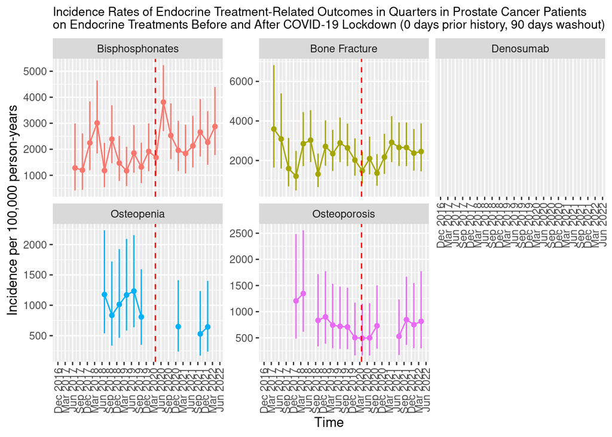

#### (365 days prior history, 90 days washout)

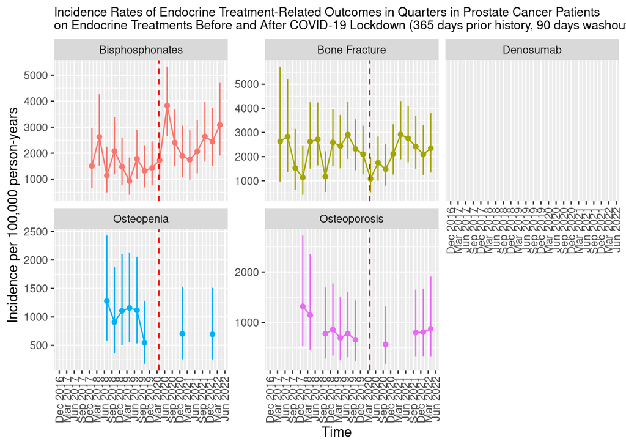

### Questions for the team:

#### 1. Are we interested in the prevalence of these drugs over time? Or just how COVID affected new prescriptions (incidence)?

#### 2. What could account for the decreasing trend in incidence of these drugs? No policy changes over time.

- potential regional differences
- potential reduction in cancers over time (though can not find data on this)
- potential increase in use of other treatments

#### 3. Are we interested in forecasting trends across the COVID period based on these data?

- possibly not due to the decreasing trend

#### 4. Are we interested in running ARIMA time-series analsyes?

- this method can account for aut-correlation between data points, seasonality, other time trends

#### 5. Are we interested in performing a large scale characterisation of these cohorts?

- breast / prostate cancer patients
- breast cancer patients on AIs / breast cancer patients on TAM / prostate cancer patients on any endocrine tx

#### 6. Are we interested in running treatment patterns of the breast and prostate cancer patients?

- would this be limited to endocrine treatments?
- stratified by age (given the difference in prescriptions by menospausal status)?